# rough_work

Hannes

2023-03-21

# 1 Data

Premier league data from 4 seasons, where 2021-2022 season was in covid without fans. We merge the data from the different seasons together, include a covid factor variable and exclude all the data from the betting.

change name of variables to snake_case

Try out first model just to get an overview if there could be effect (but doesn’t say why there is an effect). show table and anova table.

```
##
## fulltime_result   0   1   2
##               A 211 153 153
##               D 137  83  83
##               H 292 144 144
```

```
## Analysis of Deviance Table (Type II tests)
##
## Response: freq
##        LR Chisq Df Pr(>Chisq)
## winner   96.388  2  < 2.2e-16 ***
## covid    92.017  2  < 2.2e-16 ***
## ---
## Signif. codes:  0 '***' 0.001 '**' 0.01 '*' 0.05 '.' 0.1 ' ' 1
```

These results suggest that there is a covid effect present. Now we try to answer whether it comes from. (is it statistically significant?)

# 2 poisson reg

We want to fit a model for the fulltime goals as a response using poisson regression. So we need to change the form of our dataset because for now in each observation (1 game) we have the information about homegoals and awaygoals. So we create a dataframe such that each match is coded up twice, once from the hometeam perspective indicating how many times the home team scored in that match and once from the awayteam perspective indicating how many times the away team scored in that match. So we include a binary variable called “home” indicating if the goals scored are from the hometeam (1) or from the awayteam (0). So next to the factors “hometeam”, “awayteam” and “home” we also include a “covid” factor as predictors for the goals scored.

## 2.1 Quantify home effect before covid

First create model only for season before covid to quantify home effect. So we model the response fulltime goals with the predictors hometeam, awayteam and a binary predictor home that tells if the corresponding goals correspond to the hometeam (1) or to the awayteam (0).

```
##     home1
## 0.1940104
```

We can then look at the coefficient of the binary predictor “home” to quantify the home effect before covid. The value of the coefficient “home” is 0.1940104, which we can interpret as follows: The expected number of goals scored increases by a multiplicative factor of $e^{0.1940104} = 1.214109$ if a premier league team plays at home instead of away. This clearly suggests that there was a home effect present before covid in the english premier league.

Now we can test whether this home effect reduced during covid, so we also include the covid season into our model together with a binary variable covid. We then compare it to a model with the same preductors but also an interaction term between home and covid and run an anova model submodel test.

```
## Analysis of Deviance Table
##
## Model 1: fulltime_goals ~ home_team + away_team + covid + home
## Model 2: fulltime_goals ~ home_team + away_team + covid + home + covid:home
##   Resid. Df Resid. Dev Df Deviance Pr(>Chi)
## 1      1989     2529.1
## 2      1988     2523.4  1   5.6267  0.01769 *
## ---
## Signif. codes:  0 '***' 0.001 '**' 0.01 '*' 0.05 '.' 0.1 ' ' 1
```

The anova test suggests us to keep the interaction between home and covid. So we can look at the values of the coefficients covid and home:covid to see how the home effect changed during covid.

So we build a model with the goals scored as a response.

```
## Analysis of Deviance Table
##
## Model 1: fulltime_goals ~ (home_team + away_team + covid + home) - 1
## Model 2: fulltime_goals ~ home_team + away_team + covid + home + home:covid -
##     1
##   Resid. Df Resid. Dev Df Deviance Pr(>Chi)
## 1      2747     3514.4
## 2      2746     3509.0  1   5.3631  0.02057 *
## ---
## Signif. codes:  0 '***' 0.001 '**' 0.01 '*' 0.05 '.' 0.1 ' ' 1
```

We see that the model with the interaction is significant at level 0.05. So we keep this model and can look at the parameters associated to the binary predictor covid and the association between covid and home.

| Coefficient Name | Coefficient Value |
| --- | --- |
| covid | 0.0526329 |
| home:covid | -0.1688694 |

We can interpret these coefficients as follows: The expected number of home goals in a match change by a multiplicative factor of $e^{0.0526329-0.1688694} = 0.8902647$ during coivid (i.e. when there are no fans in the stadium). Conversely, the expected number of away goals in a match change by a multiplicative factor of $e^{0.0526329} = 1.054043$ during covid. So our model suggests us that there clearly is a home effect, i.e. the hometeam scores less goals without fans allowed and the awayteam scores slightly more goals without fans in the stadium of the home team. We can also look at 95% confidence intervals of these coeficients.

|  | 2.5 % | 97.5 % |
| --- | --- | --- |
| covid | -0.0567641 | 0.1605962 |
| covid:home | -0.3118095 | -0.0259571 |

So the interpretable confidence intervals for these confidence intervals are obtained by exponentiating the entries.

|  | 2.5 % | 97.5 % |
| --- | --- | --- |
| covid | 0.9448169 | 1.1742108 |
| covid:home | 0.7321210 | 0.9743769 |

So we perform residual analyses for our model.

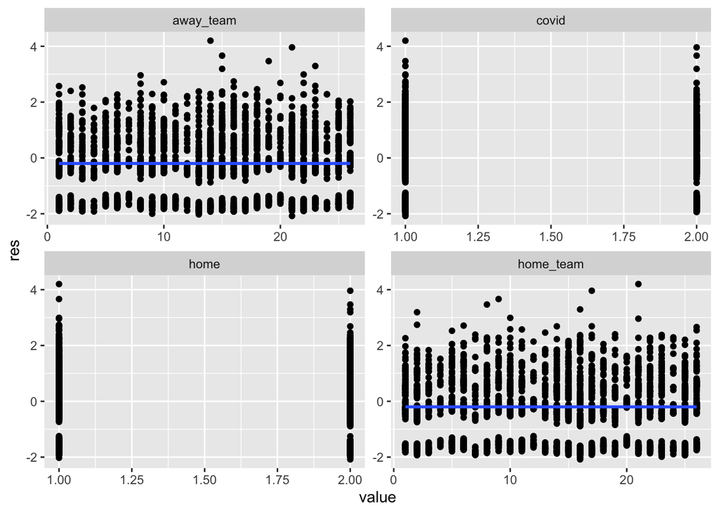

Check assumption for equal variance and mean of the response. Ideally we would check for each subgroup of the data (e.g. number of homegoals from ManU vs ManCity during covid) if we have equal variance and mean, but these would be way too many subgroups with too few observations. But we can at least check all the homegoals and all the awaygoals have equal variance and mean.

|  | Homegoals | Awaygoals |
| --- | --- | --- |
| Mean | 1.478571 | 1.295714 |
| Variance | 1.683601 | 1.515064 |

Dont have equal variance and mean - still ok?

Maybe include the variable covid as a 3 way factor (pre covid, covid, post covid) to also answer if home effect came back.